# Assignment 3

Alejandro Medina Perelló, Zygmut

2023-12-06

## Introduction

This assignment explores the Cirrhosis dataset. The research question focuses on predicting the survival state of patients with liver cirrhosis using classification models like:

- Perceptrons
- Decision trees
- Nearest neighbors
- etc

The assignment emphasizes the comparison of models and seeks to determine the best-performing model for predicting patient survival.

## Packages

```r
library(GGally)
library(tidymodels)
```

## Load dataset

```r
df <- read.csv("C:\\Users\\Eden\\Documents\\projects\\21746-data-mining\\03\\data\\cirrhosis.csv")

summary(df)
```

```
##        ID            N_Days        Status              Drug
##  Min.   :  1.0   Min.   :  41   Length:418         Length:418
##  1st Qu.:105.2   1st Qu.:1093   Class :character   Class :character
##  Median :209.5   Median :1730   Mode  :character   Mode  :character
##  Mean   :209.5   Mean   :1918
##  3rd Qu.:313.8   3rd Qu.:2614
##  Max.   :418.0   Max.   :4795
##
##       Age            Sex              Ascites          Hepatomegaly
##  Min.   : 9598   Length:418         Length:418         Length:418
##  1st Qu.:15644   Class :character   Class :character   Class :character
##  Median :18628   Mode  :character   Mode  :character   Mode  :character
##  Mean   :18533
##  3rd Qu.:21273
##  Max.   :28650
##
##    Spiders             Edema             Bilirubin       Cholesterol
##  Length:418         Length:418         Min.   : 0.300   Min.   : 120.0
##  Class :character   Class :character   1st Qu.: 0.800   1st Qu.: 249.5
##  Mode  :character   Mode  :character   Median : 1.400   Median : 309.5
##                                        Mean   : 3.221   Mean   : 369.5
##                                        3rd Qu.: 3.400   3rd Qu.: 400.0
##                                        Max.   :28.000   Max.   :1775.0
##                                                         NA's   :134
##     Albumin          Copper          Alk_Phos            SGOT
##  Min.   :1.960   Min.   :  4.00   Min.   :  289.0   Min.   : 26.35
##  1st Qu.:3.243   1st Qu.: 41.25   1st Qu.:  871.5   1st Qu.: 80.60
##  Median :3.530   Median : 73.00   Median : 1259.0   Median :114.70
##  Mean   :3.497   Mean   : 97.65   Mean   : 1982.7   Mean   :122.56
##  3rd Qu.:3.770   3rd Qu.:123.00   3rd Qu.: 1980.0   3rd Qu.:151.90
##  Max.   :4.640   Max.   :588.00   Max.   :13862.4   Max.   :457.25
##                  NA's   :108      NA's   :106       NA's   :106
##  Tryglicerides      Platelets      Prothrombin        Stage
##  Min.   : 33.00   Min.   : 62.0   Min.   : 9.00   Min.   :1.000
##  1st Qu.: 84.25   1st Qu.:188.5   1st Qu.:10.00   1st Qu.:2.000
##  Median :108.00   Median :251.0   Median :10.60   Median :3.000
##  Mean   :124.70   Mean   :257.0   Mean   :10.73   Mean   :3.024
##  3rd Qu.:151.00   3rd Qu.:318.0   3rd Qu.:11.10   3rd Qu.:4.000
##  Max.   :598.00   Max.   :721.0   Max.   :18.00   Max.   :4.000
##  NA's   :136      NA's   :11      NA's   :2       NA's   :6
```

```r
str(df)
```

```
## 'data.frame':    418 obs. of  20 variables:
##  $ ID           : int  1 2 3 4 5 6 7 8 9 10 ...
##  $ N_Days       : int  400 4500 1012 1925 1504 2503 1832 2466 2400 51 ...
##  $ Status       : chr  "D" "C" "D" "D" ...
##  $ Drug         : chr  "D-penicillamine" "D-penicillamine" "D-penicillamine" "D-penicillamine" ...
##  $ Age          : int  21464 20617 25594 19994 13918 24201 20284 19379 15526 25772 ...
##  $ Sex          : chr  "F" "F" "M" "F" ...
##  $ Ascites      : chr  "Y" "N" "N" "N" ...
##  $ Hepatomegaly : chr  "Y" "Y" "N" "Y" ...
##  $ Spiders      : chr  "Y" "Y" "N" "Y" ...
##  $ Edema        : chr  "Y" "N" "S" "S" ...
##  $ Bilirubin    : num  14.5 1.1 1.4 1.8 3.4 0.8 1 0.3 3.2 12.6 ...
##  $ Cholesterol  : int  261 302 176 244 279 248 322 280 562 200 ...
##  $ Albumin      : num  2.6 4.14 3.48 2.54 3.53 3.98 4.09 4 3.08 2.74 ...
##  $ Copper       : int  156 54 210 64 143 50 52 52 79 140 ...
##  $ Alk_Phos     : num  1718 7395 516 6122 671 ...
##  $ SGOT         : num  137.9 113.5 96.1 60.6 113.2 ...
##  $ Tryglicerides: int  172 88 55 92 72 63 213 189 88 143 ...
##  $ Platelets    : int  190 221 151 183 136 NA 204 373 251 302 ...
##  $ Prothrombin  : num  12.2 10.6 12 10.3 10.9 11 9.7 11 11 11.5 ...
##  $ Stage        : int  4 3 4 4 3 3 3 3 2 4 ...
```

## Cleaning process

### Non interesting values

To streamline the analysis, non-informative values such as unique identifiers `ID` are excluded from the dataset

```r
df <- df |> select(-ID)
```

### Categorical reconstruction

Given our research question focused on predicting whether an individual is alive after a certain period, we can simplify the survival classes by merging `CL` into `C`

```r
df <- df |> mutate(Status = ifelse(Status == "CL", "C", Status))

summary(tibble(Status = as.factor(df$Status)))
```

```
##  Status
##  C:257
##  D:161
```

### Nan values

This code snippet helps pinpoint columns containing NaN values, facilitating a more targeted exploration of missing data in the dataset.

```r
na_counts <- tibble(
  column = names(df),
  nan_count = colSums(is.na(df))
)

as.data.frame(na_counts[na_counts$nan_count > 0, ])
```

```
##           column nan_count
## 1           Drug       106
## 2        Ascites       106
## 3   Hepatomegaly       106
## 4        Spiders       106
## 5    Cholesterol       134
## 6         Copper       108
## 7       Alk_Phos       106
## 8           SGOT       106
## 9  Tryglicerides       136
## 10     Platelets        11
## 11   Prothrombin         2
## 12         Stage         6
```

As the dataset has `NaN` values, we’ll study each case

#### Non Drug patients

We’ll mutate the data from the 106 patients that didn’t take the drug as a new category `None`.

```r
faulty_data <- df |>
  filter(is.na(Drug)) |>
  select(where(~ all(is.na(.))))

summary(
  as.data.frame(faulty_data |> mutate(across(where(is.character), as.factor)))
)
```

```
##    Drug     Ascites    Hepatomegaly Spiders     Cholesterol      Copper
##  NA's:106   NA's:106   NA's:106     NA's:106   Min.   : NA   Min.   : NA
##                                                1st Qu.: NA   1st Qu.: NA
##                                                Median : NA   Median : NA
##                                                Mean   :NaN   Mean   :NaN
##                                                3rd Qu.: NA   3rd Qu.: NA
##                                                Max.   : NA   Max.   : NA
##                                                NA's   :106   NA's   :106
##     Alk_Phos        SGOT     Tryglicerides
##  Min.   : NA   Min.   : NA   Min.   : NA
##  1st Qu.: NA   1st Qu.: NA   1st Qu.: NA
##  Median : NA   Median : NA   Median : NA
##  Mean   :NaN   Mean   :NaN   Mean   :NaN
##  3rd Qu.: NA   3rd Qu.: NA   3rd Qu.: NA
##  Max.   : NA   Max.   : NA   Max.   : NA
##  NA's   :106   NA's   :106   NA's   :106
```

We can se that all of the patients that didn’t took the drug have `Drug`, `Ascites`, `Hepatomegaly`, `Spiders`, `Cholesterol`, `Copper`, `Alk_Phos`, `SGOT` and `Tryglicerides` as `NaN`. We’ll replace these `NaN` values to `None` in case of the character based variables and the `mean` to the numeric ones; As we don’t want to loose this data and we can easily identify who was in the study or not.

```r
df <- df |> mutate_at(
  vars(all_of(faulty_data |> select(where(is.character)) |> colnames())),
  ~ ifelse(is.na(.), "None", .)
)

df <- df |> mutate_at(
  vars(all_of(
    faulty_data |> select(where(is.numeric) | where(is.integer)) |> colnames()
  )),
  ~ ifelse(is.na(.), mean(., na.rm = TRUE), .)
)

summary(df[c("Cholesterol", "Copper", "Alk_Phos", "SGOT", "Tryglicerides")])
```

```
##   Cholesterol         Copper          Alk_Phos          SGOT
##  Min.   : 120.0   Min.   :  4.00   Min.   :  289   Min.   : 26.35
##  1st Qu.: 273.0   1st Qu.: 51.25   1st Qu.: 1016   1st Qu.: 91.00
##  Median : 369.5   Median : 97.65   Median : 1717   Median :122.56
##  Mean   : 369.5   Mean   : 97.65   Mean   : 1983   Mean   :122.56
##  3rd Qu.: 369.5   3rd Qu.:100.75   3rd Qu.: 1983   3rd Qu.:135.75
##  Max.   :1775.0   Max.   :588.00   Max.   :13862   Max.   :457.25
##  Tryglicerides
##  Min.   : 33.0
##  1st Qu.: 95.0
##  Median :124.7
##  Mean   :124.7
##  3rd Qu.:127.8
##  Max.   :598.0
```

#### Platelets & Prothrombin

We’ll use the same method as above to the numerical values `Platelets` and `Prothrombin`

```r
df <- df |> mutate_at(
  vars(all_of(c("Platelets", "Prothrombin"))),
  ~ ifelse(is.na(.), mean(., na.rm = TRUE), .)
)

summary(df[c("Platelets", "Prothrombin")])
```

```
##    Platelets      Prothrombin
##  Min.   : 62.0   Min.   : 9.00
##  1st Qu.:190.0   1st Qu.:10.00
##  Median :253.0   Median :10.60
##  Mean   :257.0   Mean   :10.73
##  3rd Qu.:315.5   3rd Qu.:11.10
##  Max.   :721.0   Max.   :18.00
```

#### Stage

As it has a relationship with the severity of the disease, we cannot convert it into a factor as stage is an ordinal variable, indicating different levels or stages of severity. As such, we’ll use the median of the value.

```r
df <- df |> mutate_at(
  vars("Stage"),
  ~ ifelse(is.na(.), median(., na.rm = TRUE), .)
)

summary(tibble(Stage = df$Stage))
```

```
##      Stage
##  Min.   :1.000
##  1st Qu.:2.000
##  Median :3.000
##  Mean   :3.024
##  3rd Qu.:4.000
##  Max.   :4.000
```

### Factors

As a last step, we’ll change any character-based variable into a factor

```r
df <- df |> mutate_if(is.character, as.factor)

summary(as.data.frame(df |> select(where(is.factor))))
```

```
##  Status               Drug     Sex     Ascites    Hepatomegaly Spiders
##  C:257   D-penicillamine:158   F:374   N   :288   N   :152     N   :222
##  D:161   None           :106   M: 44   None:106   None:106     None:106
##          Placebo        :154           Y   : 24   Y   :160     Y   : 90
##  Edema
##  N:354
##  S: 44
##  Y: 20
```

Finally we can re-inspect the whole data

```r
summary(df)
```

```
##      N_Days     Status               Drug          Age        Sex
##  Min.   :  41   C:257   D-penicillamine:158   Min.   : 9598   F:374
##  1st Qu.:1093   D:161   None           :106   1st Qu.:15644   M: 44
##  Median :1730           Placebo        :154   Median :18628
##  Mean   :1918                                 Mean   :18533
##  3rd Qu.:2614                                 3rd Qu.:21273
##  Max.   :4795                                 Max.   :28650
##  Ascites    Hepatomegaly Spiders    Edema     Bilirubin       Cholesterol
##  N   :288   N   :152     N   :222   N:354   Min.   : 0.300   Min.   : 120.0
##  None:106   None:106     None:106   S: 44   1st Qu.: 0.800   1st Qu.: 273.0
##  Y   : 24   Y   :160     Y   : 90   Y: 20   Median : 1.400   Median : 369.5
##                                             Mean   : 3.221   Mean   : 369.5
##                                             3rd Qu.: 3.400   3rd Qu.: 369.5
##                                             Max.   :28.000   Max.   :1775.0
##     Albumin          Copper          Alk_Phos          SGOT
##  Min.   :1.960   Min.   :  4.00   Min.   :  289   Min.   : 26.35
##  1st Qu.:3.243   1st Qu.: 51.25   1st Qu.: 1016   1st Qu.: 91.00
##  Median :3.530   Median : 97.65   Median : 1717   Median :122.56
##  Mean   :3.497   Mean   : 97.65   Mean   : 1983   Mean   :122.56
##  3rd Qu.:3.770   3rd Qu.:100.75   3rd Qu.: 1983   3rd Qu.:135.75
##  Max.   :4.640   Max.   :588.00   Max.   :13862   Max.   :457.25
##  Tryglicerides     Platelets      Prothrombin        Stage
##  Min.   : 33.0   Min.   : 62.0   Min.   : 9.00   Min.   :1.000
##  1st Qu.: 95.0   1st Qu.:190.0   1st Qu.:10.00   1st Qu.:2.000
##  Median :124.7   Median :253.0   Median :10.60   Median :3.000
##  Mean   :124.7   Mean   :257.0   Mean   :10.73   Mean   :3.024
##  3rd Qu.:127.8   3rd Qu.:315.5   3rd Qu.:11.10   3rd Qu.:4.000
##  Max.   :598.0   Max.   :721.0   Max.   :18.00   Max.   :4.000
```

```r
str(df)
```

```
## 'data.frame':    418 obs. of  19 variables:
##  $ N_Days       : int  400 4500 1012 1925 1504 2503 1832 2466 2400 51 ...
##  $ Status       : Factor w/ 2 levels "C","D": 2 1 2 2 1 2 1 2 2 2 ...
##  $ Drug         : Factor w/ 3 levels "D-penicillamine",..: 1 1 1 1 3 3 3 3 1 3 ...
##  $ Age          : int  21464 20617 25594 19994 13918 24201 20284 19379 15526 25772 ...
##  $ Sex          : Factor w/ 2 levels "F","M": 1 1 2 1 1 1 1 1 1 1 ...
##  $ Ascites      : Factor w/ 3 levels "N","None","Y": 3 1 1 1 1 1 1 1 1 3 ...
##  $ Hepatomegaly : Factor w/ 3 levels "N","None","Y": 3 3 1 3 3 3 3 1 1 1 ...
##  $ Spiders      : Factor w/ 3 levels "N","None","Y": 3 3 1 3 3 1 1 1 3 3 ...
##  $ Edema        : Factor w/ 3 levels "N","S","Y": 3 1 2 2 1 1 1 1 1 3 ...
##  $ Bilirubin    : num  14.5 1.1 1.4 1.8 3.4 0.8 1 0.3 3.2 12.6 ...
##  $ Cholesterol  : num  261 302 176 244 279 248 322 280 562 200 ...
##  $ Albumin      : num  2.6 4.14 3.48 2.54 3.53 3.98 4.09 4 3.08 2.74 ...
##  $ Copper       : num  156 54 210 64 143 50 52 52 79 140 ...
##  $ Alk_Phos     : num  1718 7395 516 6122 671 ...
##  $ SGOT         : num  137.9 113.5 96.1 60.6 113.2 ...
##  $ Tryglicerides: num  172 88 55 92 72 63 213 189 88 143 ...
##  $ Platelets    : num  190 221 151 183 136 ...
##  $ Prothrombin  : num  12.2 10.6 12 10.3 10.9 11 9.7 11 11 11.5 ...
##  $ Stage        : num  4 3 4 4 3 3 3 3 2 4 ...
```

## Case study

### Categorical study

First of all, let’s see the number of patients of each type to see how they are distributed. This will be useful to be able to see how many patients of each stage present different symptoms.

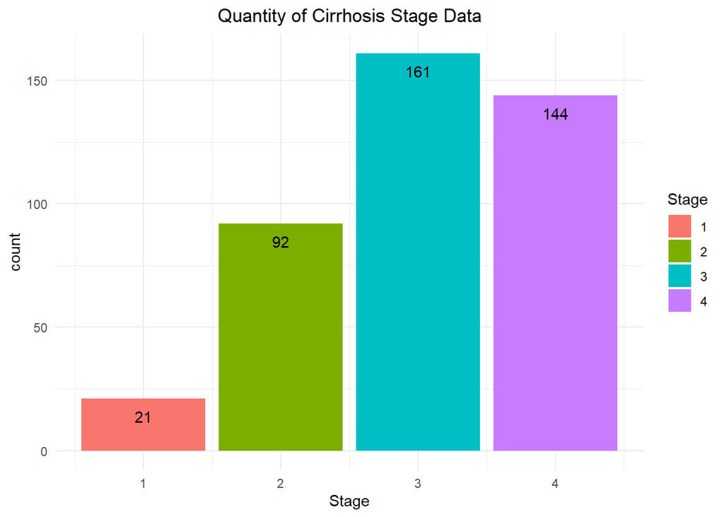

```r
ggplot(df, aes(x = Stage, fill = as.factor(Stage))) +
  geom_bar(stat = "Count") +
  geom_text(
    stat = "Count",
    aes(label = after_stat(count)),
    vjust = 2
  ) +
  labs(
    title = "Quantity of Cirrhosis Stage Data",
    fill = "Stage"
  ) +
  theme_minimal() +
  theme(plot.title = element_text(hjust = 0.5))
```

The plot presents a left-skewed distributions of values. This could potentially hinder our model performace, as the data presents a clear unbalance of classes.

There’s also the merit of checking the distribution of values regarding our clasification variable `Status`

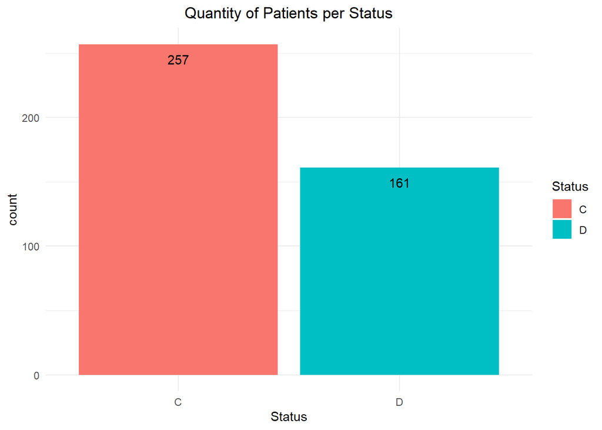

```r
ggplot(df, aes(x = Status, fill = as.factor(Status))) +
  geom_bar(stat = "Count") +
  geom_text(
    stat = "Count",
    aes(label = after_stat(count)),
    vjust = 2
  ) +
  labs(
    title = "Quantity of Patients per Status",
    fill = "Status"
  ) +
  theme_minimal() +
  theme(plot.title = element_text(hjust = 0.5))
```

Now we are going to look at each group of patients distributed by their stage to see how many of them consume a specific type of drug.

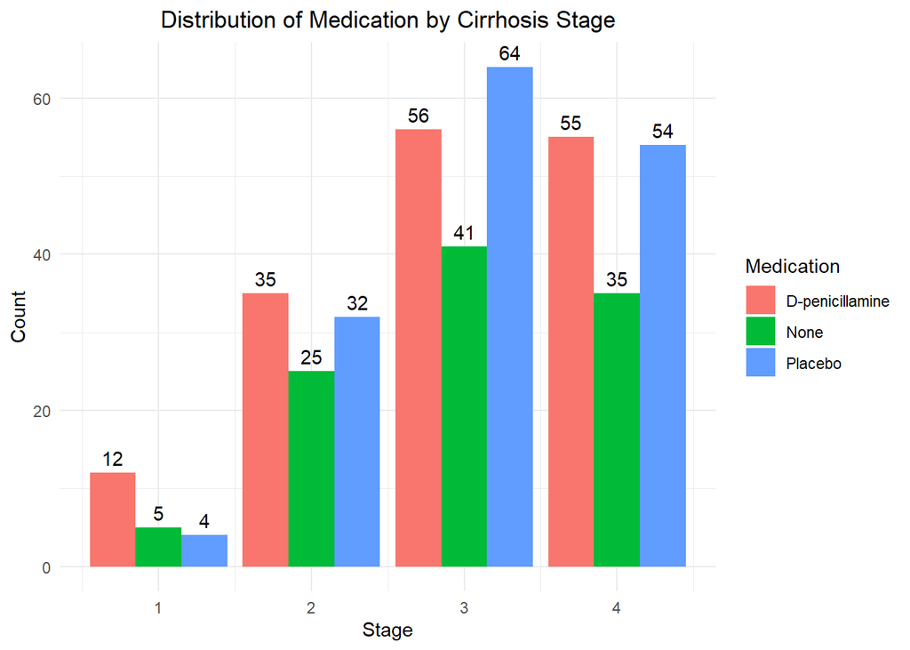

```r
ggplot(df, aes(x = Stage, fill = Drug)) +
  geom_bar(stat = "count", position = "dodge") +
  geom_text(
    stat = "count",
    aes(label = after_stat(count)),
    position = position_dodge(width = 0.9),
    vjust = -0.5
  ) +
  labs(
    title = "Distribution of Medication by Cirrhosis Stage",
    x = "Stage",
    y = "Count"
  ) +
  theme_minimal() +
  theme(plot.title = element_text(hjust = 0.5)) +
  guides(fill = guide_legend(title = "Medication"))
```

### Quantitative study

Finally, we can provide the correlation matrix to observe the pairwise relationships between variables, allowing us to uncover patterns.

```r
ggcorr(
  df |> select(-where(is.factor)),
  label = TRUE,
  label_round = 2,
  hjust = 0.75,
  angle = -45
)
```

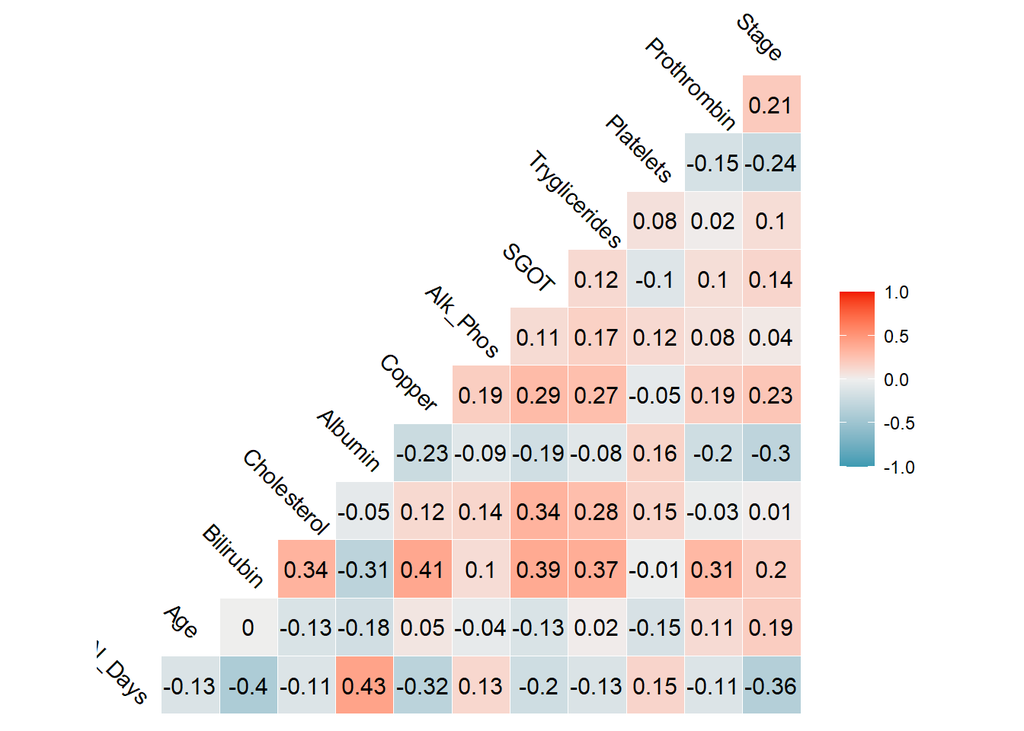

With this data, we can more tightly define what values are going to be used in our models. The selection will be purely by correlation overall significance (i.e. Age doesn’t seem to be very correlated with any other value)

```r
correlation_threshold <- 2

corr_matrix <- cor(df |> select(-where(is.factor)))
thresholds <- sapply(data.frame(corr_matrix), function(x) sum(abs(x)) - 1)
threshold_names <- names(thresholds[thresholds > correlation_threshold])
```

We can finally create cleaned up dataframe that will be used for the training of the models

```r
cleaned_df <- df[, c(threshold_names, names(df |> select(where(is.factor))))]
summary(cleaned_df)
```

```
##      N_Days       Bilirubin         Albumin          Copper
##  Min.   :  41   Min.   : 0.300   Min.   :1.960   Min.   :  4.00
##  1st Qu.:1093   1st Qu.: 0.800   1st Qu.:3.243   1st Qu.: 51.25
##  Median :1730   Median : 1.400   Median :3.530   Median : 97.65
##  Mean   :1918   Mean   : 3.221   Mean   :3.497   Mean   : 97.65
##  3rd Qu.:2614   3rd Qu.: 3.400   3rd Qu.:3.770   3rd Qu.:100.75
##  Max.   :4795   Max.   :28.000   Max.   :4.640   Max.   :588.00
##       SGOT            Stage       Status               Drug     Sex
##  Min.   : 26.35   Min.   :1.000   C:257   D-penicillamine:158   F:374
##  1st Qu.: 91.00   1st Qu.:2.000   D:161   None           :106   M: 44
##  Median :122.56   Median :3.000           Placebo        :154
##  Mean   :122.56   Mean   :3.024
##  3rd Qu.:135.75   3rd Qu.:4.000
##  Max.   :457.25   Max.   :4.000
##  Ascites    Hepatomegaly Spiders    Edema
##  N   :288   N   :152     N   :222   N:354
##  None:106   None:106     None:106   S: 44
##  Y   : 24   Y   :160     Y   : 90   Y: 20
##
##
##
```

```r
str(cleaned_df)
```

```
## 'data.frame':    418 obs. of  13 variables:
##  $ N_Days      : int  400 4500 1012 1925 1504 2503 1832 2466 2400 51 ...
##  $ Bilirubin   : num  14.5 1.1 1.4 1.8 3.4 0.8 1 0.3 3.2 12.6 ...
##  $ Albumin     : num  2.6 4.14 3.48 2.54 3.53 3.98 4.09 4 3.08 2.74 ...
##  $ Copper      : num  156 54 210 64 143 50 52 52 79 140 ...
##  $ SGOT        : num  137.9 113.5 96.1 60.6 113.2 ...
##  $ Stage       : num  4 3 4 4 3 3 3 3 2 4 ...
##  $ Status      : Factor w/ 2 levels "C","D": 2 1 2 2 1 2 1 2 2 2 ...
##  $ Drug        : Factor w/ 3 levels "D-penicillamine",..: 1 1 1 1 3 3 3 3 1 3 ...
##  $ Sex         : Factor w/ 2 levels "F","M": 1 1 2 1 1 1 1 1 1 1 ...
##  $ Ascites     : Factor w/ 3 levels "N","None","Y": 3 1 1 1 1 1 1 1 1 3 ...
##  $ Hepatomegaly: Factor w/ 3 levels "N","None","Y": 3 3 1 3 3 3 3 1 1 1 ...
##  $ Spiders     : Factor w/ 3 levels "N","None","Y": 3 3 1 3 3 1 1 1 3 3 ...
##  $ Edema       : Factor w/ 3 levels "N","S","Y": 3 1 2 2 1 1 1 1 1 3 ...
```

## Learning models

### Data split

It’s always a best practice to verify the dimensions of both datasets. We are checking whether the split between the training and testing sets is consistent with the specified ratio. We will consider differences starting from the second decimal place onward, as small discrepancies may occur due to the representation of numbers in floating-point format.

```r
split_ratio <- 0.8
data_split <- initial_split(cleaned_df, prop = split_ratio)

ifelse(
  all(c(
    isTRUE(all.equal(
      dim(training(data_split))[1],
      dim(cleaned_df)[1] * split_ratio,
      tolerance = 0.01
    )),
    isTRUE(all.equal(
      dim(testing(data_split))[1],
      dim(cleaned_df)[1] * (1 - split_ratio),
      tolerance = 0.01
    ))
  )),
  "They are roughly equal",
  "Too much difference!"
)
```

```
## [1] "They are roughly equal"
```

We’ll use this method in a future function to agilize the process of testing with different train/test splits.

### Utils

As per the evaluation of each model, a helper function is employed, as implemented below. From there, two key metrics, accuracy and kap, are extracted:

- Accuracy: Calculated as the ratio of correctly predicted instances to the total number of instances, quantifies the overall correctness of predictions.
- Kappa (Kap): Statistical measure that assesses the level of agreement between observed and expected classifications. More information about the kappa metric can be found [here](https://en.wikipedia.org/wiki/Cohen%27s_kappa)

```r
model_accuracy <- function(model, train, test) {
  pred <- model |>
    fit(Status ~ ., data = train) |> # nolint
    predict(test) |>
    pull(.pred_class) # nolint

  results <- test |>
    mutate(predictions = pred) |> # nolint
    metrics(truth = Status, estimate = predictions) |> # nolint
    filter(.metric %in% c("accuracy", "kap")) |> # nolint
    pivot_wider(names_from = .metric, values_from = .estimate) |> # nolint
    select(accuracy, kap) # nolint

  return(as.data.frame(results))
}
```

To streamline the use of `model_accuracy`, the function `test_model` was crafted. It allows to assess the evaluation of a model by creating the train/test data split per call.

```r
test_model <- function(model, data, split_ratio, seed) {
  set.seed(seed)

  data_split <- initial_split(data, prop = split_ratio) # nolint

  return(model_accuracy(model, training(data_split), testing(data_split))) # nolint
}
```

### Training

We dediced to use the following models (and their parameter permutations):

- Logistic regression
- Linear SVM
- Radial basis function SVM
- Perceptron
- Decision tree
- K-nearest neighbor

```r
models <- list(
  logistic_reg(
    engine = "glm"
  ),
  svm_linear(
    engine = "kernlab",
    mode = "classification"
  ),
  svm_rbf(
    margin = 0.1,
    engine = "kernlab",
    mode = "classification"
  ),
  svm_rbf(
    margin = 0.2,
    engine = "kernlab",
    mode = "classification"
  ),
  mlp(
    epochs = 100,
    hidden_units = 1, # Single perceptron in the hidden layer
    engine = "nnet",
    mode = "classification"
  ),
  decision_tree(
    engine = "rpart",
    mode = "classification"
  ),
  decision_tree(
    min_n = 5,
    engine = "rpart",
    mode = "classification"
  ),
  decision_tree(
    min_n = 8,
    engine = "rpart",
    mode = "classification"
  ),
  decision_tree(
    min_n = 8,
    engine = "rpart",
    mode = "classification"
  ),
  nearest_neighbor(
    neighbors = 5,
    weight_func = "triangular",
    engine = "kknn",
    mode = "classification"
  ),
  nearest_neighbor(
    neighbors = 10,
    weight_func = "triangular",
    engine = "kknn",
    mode = "classification"
  ),
  nearest_neighbor(
    neighbors = 15,
    weight_func = "triangular",
    engine = "kknn",
    mode = "classification"
  ),
  nearest_neighbor(
    neighbors = 5,
    weight_func = "triangular",
    engine = "kknn",
    mode = "classification"
  )
)
```

Having the list of all models to test, we assess the performance of each under varying training-test splits. These splits range from 0.2 to 0.8, representing the data proportion of the training set.

```r
model_accuracies <- map_dfr(
  lapply(
    seq(0.2, 0.8, by = 0.1),
    function(split) {
      model_accuracies <- map_dfr(
        map(models, ~ test_model(., cleaned_df, split, 27)),
        bind_rows
      ) |> mutate(index = row_number(), train_split = split)
    }
  ),
  bind_rows
)
```

### Model comparison

Finalizing the study, a couple of graph will ge shown to compare the results and efficiency of all the models outcomes

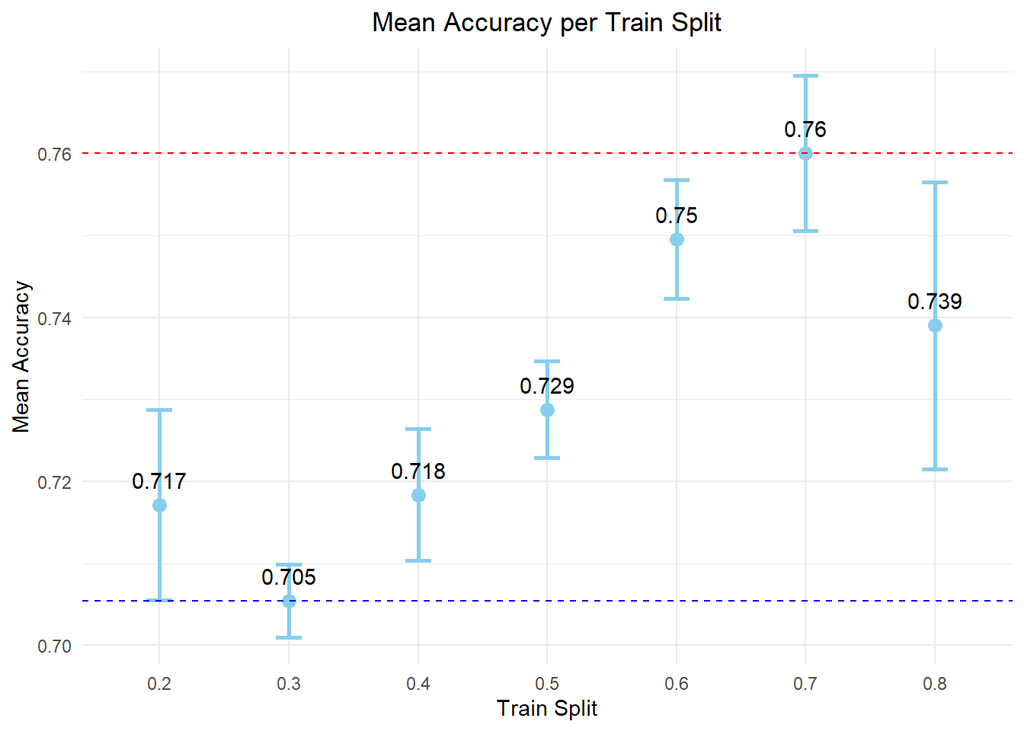

```r
group_train_acc <- model_accuracies |>
  group_by(train_split) |>
  summarize(
    mean_accuracy = mean(accuracy),
    sd_accuracy = sd(accuracy),
    se_accuracy = sd(accuracy) / sqrt(n())
  )

ggplot(group_train_acc, aes(x = as.factor(train_split), y = mean_accuracy)) +
  geom_point(color = "skyblue", size = 3) +
  geom_errorbar(
    aes(ymin = mean_accuracy - se_accuracy, ymax = mean_accuracy + se_accuracy),
    width = 0.2,
    color = "skyblue",
    linewidth = 1
  ) +
  geom_hline(
    yintercept = max(group_train_acc$mean_accuracy),
    color = "red",
    linetype = "dashed"
  ) +
  geom_hline(
    yintercept = min(group_train_acc$mean_accuracy),
    color = "blue",
    linetype = "dashed"
  ) +
  geom_text(aes(label = round(mean_accuracy, 3)), vjust = -1) +
  labs(
    title = "Mean Accuracy per Train Split",
    x = "Train Split",
    y = "Mean Accuracy"
  ) +
  theme_minimal() +
  theme(plot.title = element_text(hjust = 0.5))
```

The dashed red and blue lines indicate the maximum and minimum mean accuracy, respectively. Based on the plot, it appears that the maximum mean accuracy is around the 0.7 train split value, suggesting that the best model is expected to perform well at approximately that split ratio.

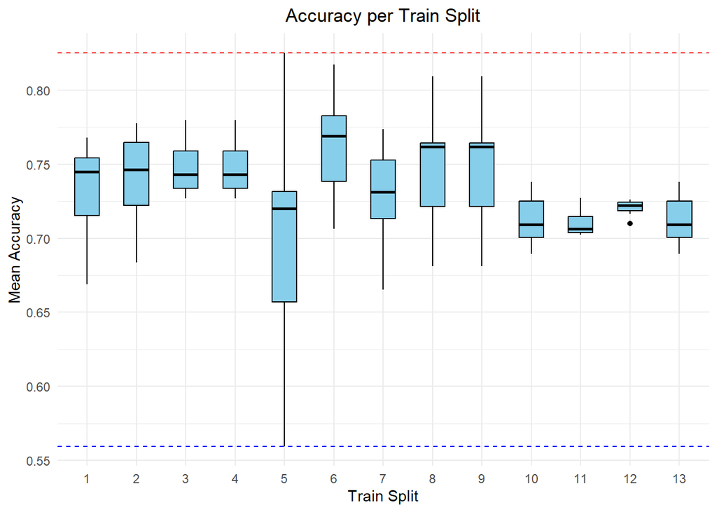

```r
ggplot(model_accuracies, aes(x = as.factor(index), y = accuracy)) +
  geom_boxplot(fill = "skyblue", color = "black", width = 0.5) +
  labs(
    title = "Accuracy per Train Split",
    x = "Train Split",
    y = "Mean Accuracy"
  ) +
  geom_hline(
    yintercept = max(model_accuracies$accuracy),
    color = "red",
    linetype = "dashed"
  ) +
  geom_hline(
    yintercept = min(model_accuracies$accuracy),
    color = "blue",
    linetype = "dashed"
  ) +
  theme_minimal() +
  theme(plot.title = element_text(hjust = 0.5))
```

Notably, the 5th model (perceptron) shows inconsistency in its accuracy values, even though it includes outlier models with the best accuracy. This inconsistency suggests that additional training data or adjustments may be needed to improve the overall performance of the perceptron model.

### Best model

Finally, we can retrive the index with the highest-performing model and show it’s details.

```r
(best_model <- model_accuracies
  |> filter(accuracy == max(accuracy))
)
```

```
##    accuracy       kap index train_split
## 1 0.8253968 0.6159601     5         0.7
```

```r
models[[best_model$index[1]]]
```

```
## Single Layer Neural Network Model Specification (classification)
##
## Main Arguments:
##   hidden_units = 1
##   epochs = 100
##
## Computational engine: nnet
```

In this specific configuration, the best one was a Single Layer Neural Network Model Specification (Single perceptron model) with an accuracy of 82% using a datasplit of 0.7.

Note that there’s no such thing as the *best* model overall and, in this specific case, we opted to label the best as the one that has the highest accuracy for the given data. One could argue that the model that gives the highest mean accuracy troughout the train/test split is the *best* as its consistency prooves it robustness.

## Conclusion

In order to address the question stated by the assesment, a comprehensive examination of the dataset was undertaken. This involved a meticulous review and adaptation of the dataset as to obtain the most amout of usable data.

Once the dataset was appropriately transformed, a careful selection of variables followed. This selection was guided by considerations such as strong inter-variable correlations and the significance of specific variables, ensuring the exclusion of superfluous information that would not contribute meaningfully to the study.

Ultimately, with a refined dataset tailored to the study’s requirements, the model generation process was issued. This involved training various models to predict the survival status of patients. Subsequently, the identification of the optimal model capable of fulfilling the predictive task was ascertained.

## Additional notes

Among all the models executed, the perceptron was the best one attaining an accuracy of 82%. Note that, knowing that this model **is** an outlier of the most inconsistent model, new data should be introduced to reassess the confidence of it. Nevertheless, within the context of the healthcare domain, it is imperative to exercise caution and consider this model as a guiding tool rather than an entirely reliable solution.

Furthermore, it is crucial to acknowledge that alterations in model parameters can significantly influence the determination of the best-performing model. Consequently, confidence in the predictions of these may not carry substantial weight in this domain.